# Analiza Korespondencji

```r
E <- (P-teor)/teor^(1/2)
str(E)
```

```
##  num [1:16, 1:12] 0.01876 -0.00531 -0.00133 0.00498 -0.00426 ...
##  - attr(*, "dimnames")=List of 2
##   ..$ : chr [1:16] "dolnośląskie" "kujawsko-pomorskie" "lubelskie" "lubuskie" ...
##   ..$ : chr [1:12] "BS" "PSL" "Lew" "PIS" ...
```

Mapy ciepła odchyłek od niezależności wyglądają następująco:

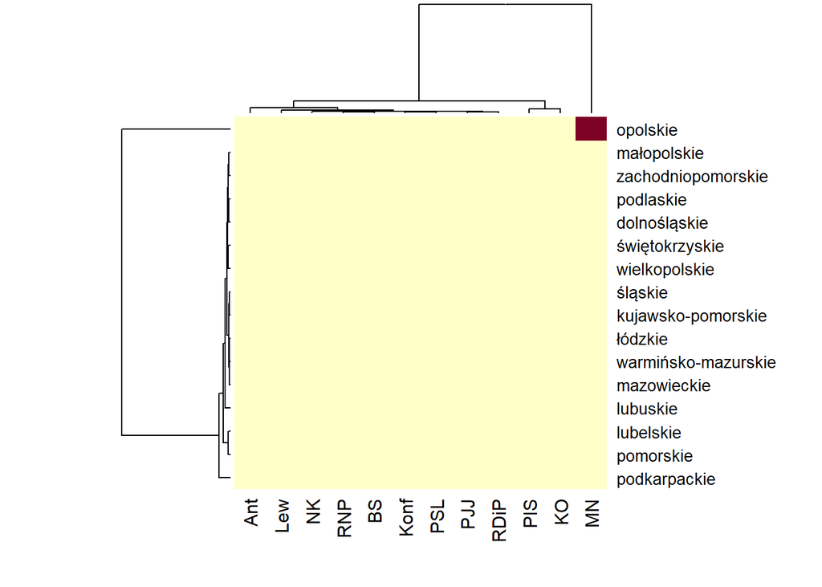

```r
heatmap(E*E, scale = "none")
```

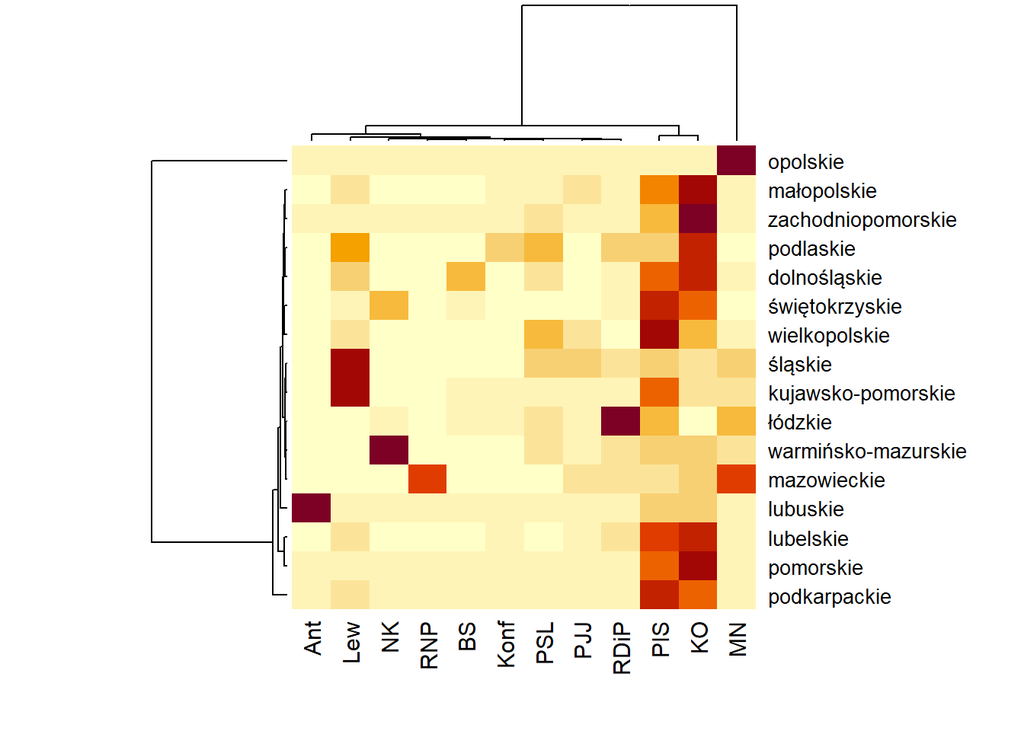

```r
heatmap(E*E, scale="row")
```

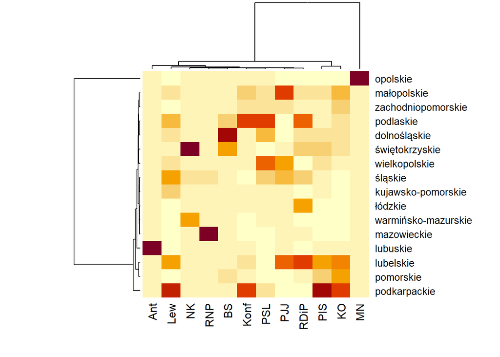

```r
heatmap(E*E, scale="col")
```

```r
S <- svd(E)
str(S)
```

```
## List of 3
##  $ d: num [1:12] 0.2304 0.1722 0.0484 0.0447 0.04 ...
##  $ u: num [1:16, 1:12] -0.01743 -0.02595 -0.07436 -0.00619 -0.04399 ...
##  $ v: num [1:12, 1:12] -0.01337 -0.0326 -0.00621 -0.09797 -0.02637 ...
```

Korzystając z powyższej dekompozycji macierzy $E\cdot E^T$ standaryzując współrzędne wierszy i kolumn otrzymujemy wykres postaci:

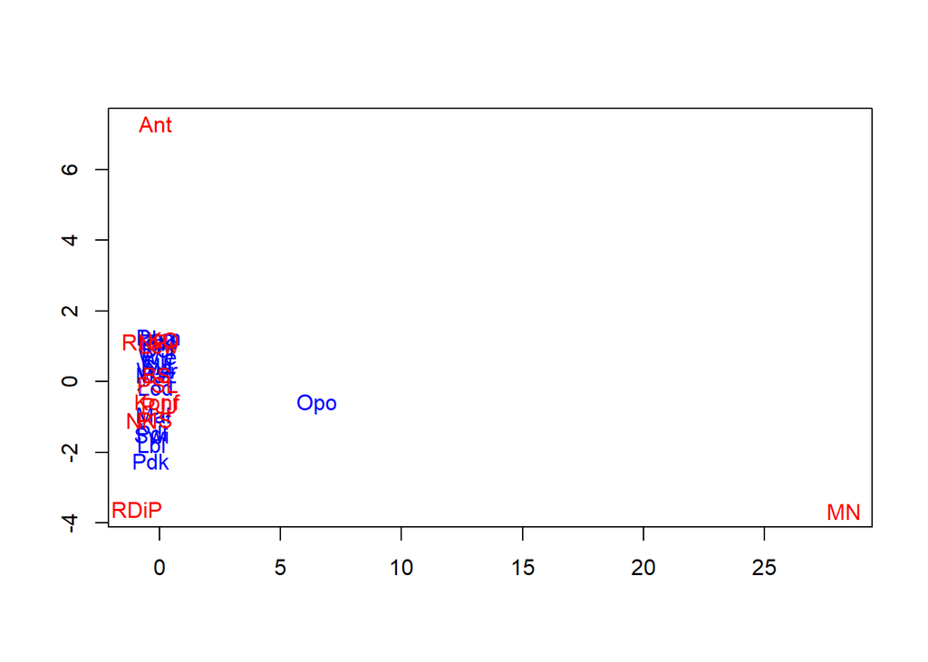

```r
X <- diag(1/sqrt(masa_w)) %*% S$u
Y <- diag(1/sqrt(masa_k)) %*% S$v
plot(rbind(X[,1:2], Y[,1:2]), col = "white", xlab = "", ylab = "", main = "")
text(X[,1:2], c("Dol", "Kuj", "Lbl", "Lbu", "Łód", "Mał", "Maz", "Opo", "Pdk", "Pdl", "Pom", "Ślą", "Świ", "War", "Wie", "Zac"), col = "blue")
text(Y[,1:2], names(wyniki_2023_woj), col = "red")
```

```r
library(rgl)
rownames(wyniki_2023_woj) <- NULL
dane <- as.matrix(wyniki_2023_woj)
plot3d(ca(dane))
rglwidget()
```

[interactive chart not shown]

# Analiza korespondencji danych bez najrzadziej wybieranych partii z podziałem na województwa

Przeprowadzimy dalej analizę korespondencji bez odstających partii politycznych tych samych, co w podziale na okręgi.

```r
rownames(wyniki_2023_woj) <- c("dolnośląskie", "kujawsko-pomorskie", "lubelskie", "lubuskie", "łódzkie", "małopolskie", "mazowieckie", "opolskie", "podkarpackie", "podlaskie", "pomorskie", "śląskie", "świętokrzyskie", "warmińsko-mazurskie", "wielkopolskie", "zachodniopomorskie")
str(wyniki_2023_woj[, 1:7])
```

```
## 'data.frame':    16 obs. of  7 variables:
##  $ BS  : int  44968 16663 19866 11954 22874 34112 59366 7521 19467 7081 ...
##  $ PSL : int  199797 164734 162471 77933 186075 306994 481728 61155 144614 114898 ...
##  $ Lew : int  161610 113432 62774 47911 122298 135415 275543 34763 52578 29478 ...
##  $ PIS : int  489339 345734 526729 143530 528393 814758 1132523 150022 589478 258277 ...
##  $ Konf: int  105380 68498 89919 33672 92058 156731 226425 31150 101934 59648 ...
##  $ KO  : int  576441 345633 211213 195091 411648 458701 1023353 161241 189313 126971 ...
##  $ PJJ : int  23749 14556 27822 5794 18691 46365 46092 8338 16169 9998 ...
```

```r
dane2 <- as.matrix(wyniki_2023_woj[, 1:7])
```

Mapy ciepła tych danych są postaci:

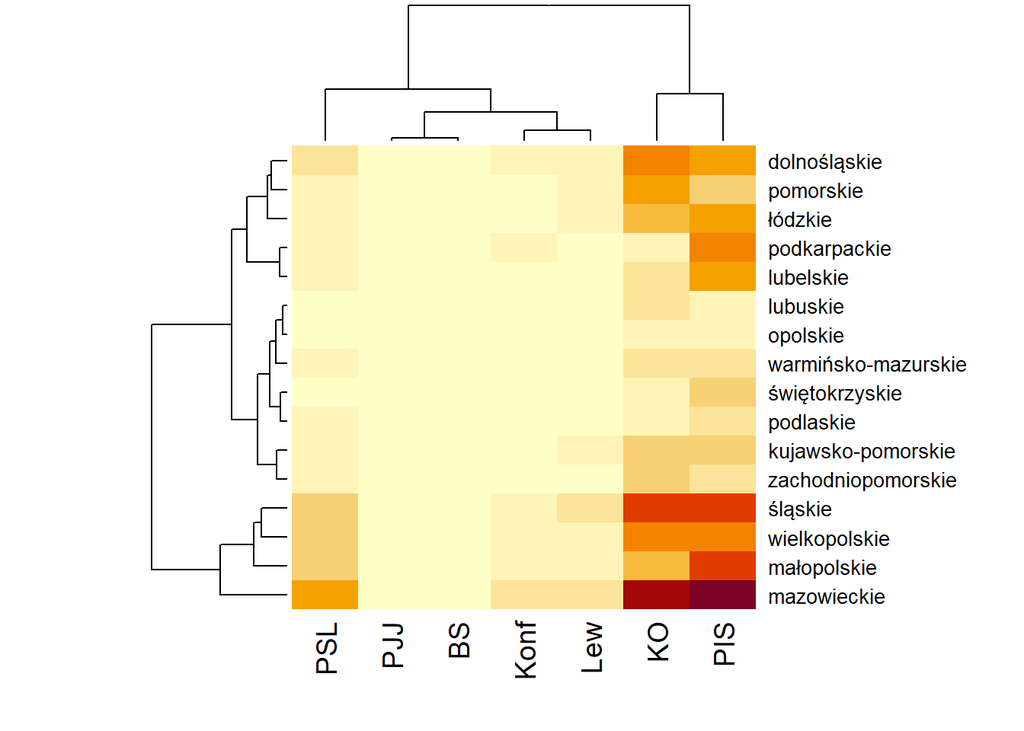

```r
heatmap(dane2, scale = "none")
```

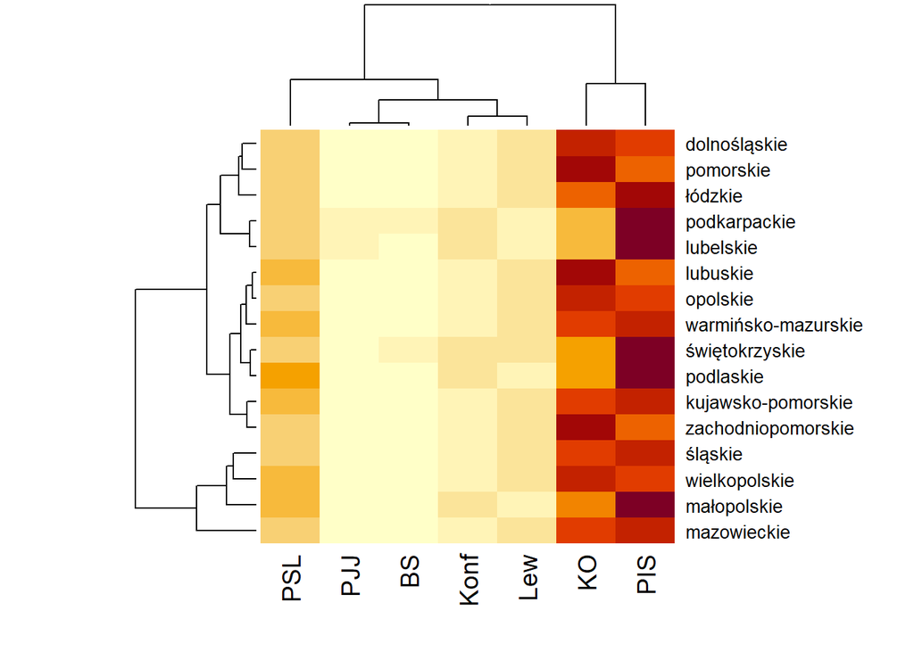

```r
heatmap(dane2, scale="row")
```

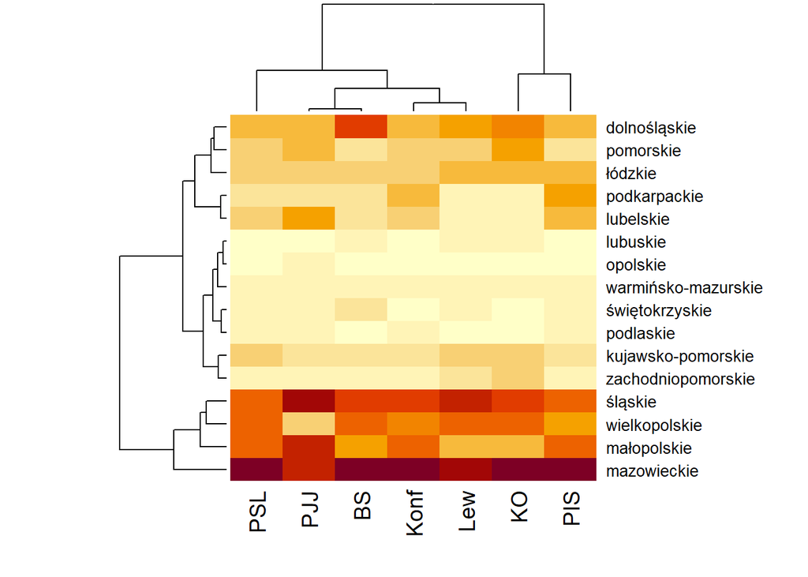

```r
heatmap(dane2, scale="col")
```

Wynikiem testu $\chi^2$ jest liczba:

```r
test2 <- chisq.test(dane2)
test2
```

```
##
##  Pearson's Chi-squared test
##
## data:  dane2
## X-squared = 721487, df = 90, p-value < 2.2e-16
```

Odrzucamy hipotezę o niezależności, więc ponownie możemy przeprowadzić analizę korespondencji w celu szukania postaci szukanej zależności.

```r
n2 <- sum(dane2)
P2 <- dane2/n2
str(P2)
```

```
##  num [1:16, 1:7] 0.002144 0.000795 0.000947 0.00057 0.001091 ...
##  - attr(*, "dimnames")=List of 2
##   ..$ : chr [1:16] "dolnośląskie" "kujawsko-pomorskie" "lubelskie" "lubuskie" ...
##   ..$ : chr [1:7] "BS" "PSL" "Lew" "PIS" ...
```

```r
masa_w <- rowSums(P2)
masa_w
```

```
##        dolnośląskie  kujawsko-pomorskie           lubelskie            lubuskie
##          0.07636185          0.05099027          0.05249454          0.02460147
##             łódzkie         małopolskie         mazowieckie            opolskie
##          0.06590642          0.09313807          0.15474862          0.02165936
##        podkarpackie           podlaskie           pomorskie             śląskie
##          0.05310299          0.02891560          0.06195543          0.11641457
##      świętokrzyskie warmińsko-mazurskie       wielkopolskie  zachodniopomorskie
##          0.03125836          0.03287899          0.09388066          0.04169280
```

```r
masa_k <- colSums(P2)
masa_k
```

```
##         BS        PSL        Lew        PIS       Konf         KO        PJJ
## 0.01882227 0.14503260 0.08471686 0.35995866 0.07135190 0.30386473 0.01625299
```

```r
teor2 <- outer(masa_w, masa_k, "*")
str(teor)
```

```
##  num [1:16, 1:12] 0.001429 0.000957 0.000987 0.000462 0.001238 ...
##  - attr(*, "dimnames")=List of 2
##   ..$ : chr [1:16] "dolnośląskie" "kujawsko-pomorskie" "lubelskie" "lubuskie" ...
##   ..$ : chr [1:12] "BS" "PSL" "Lew" "PIS" ...
```

```r
E2 <- (P2-teor2)/teor2^(1/2)
str(E2)
```

```
##  num [1:16, 1:7] 0.01865 -0.00533 -0.00129 0.00497 -0.00425 ...
##  - attr(*, "dimnames")=List of 2
##   ..$ : chr [1:16] "dolnośląskie" "kujawsko-pomorskie" "lubelskie" "lubuskie" ...
##   ..$ : chr [1:7] "BS" "PSL" "Lew" "PIS" ...
```

Mapy ciepła odchyłek od niezależności wyglądają następująco:

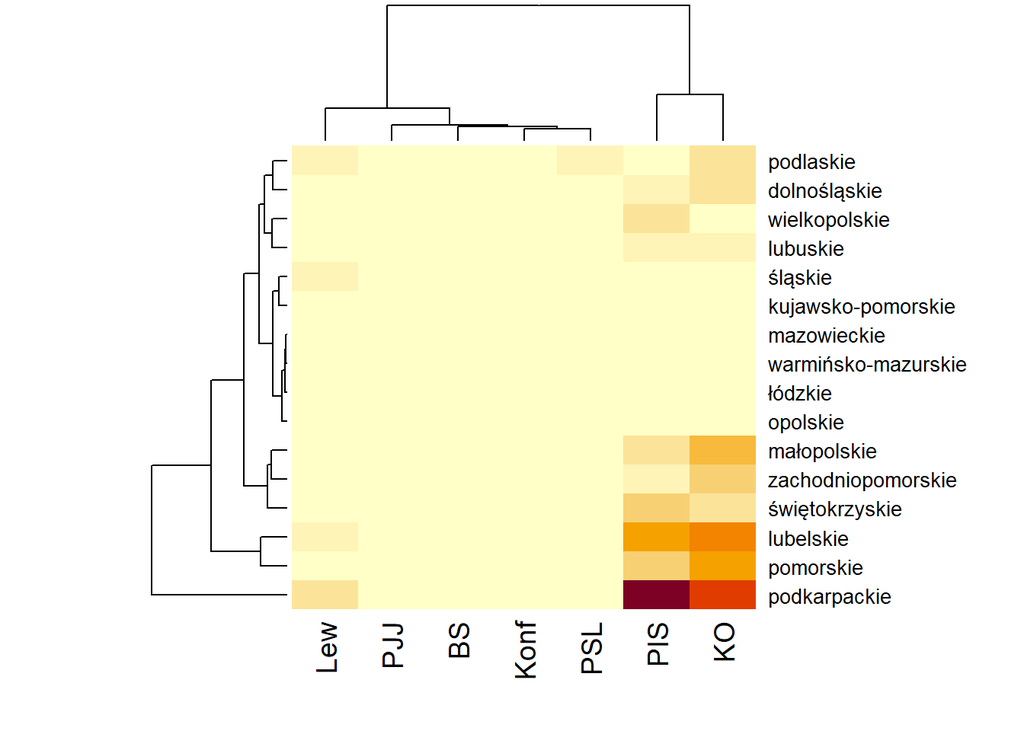

```r
heatmap(E2*E2, scale = "none")
```

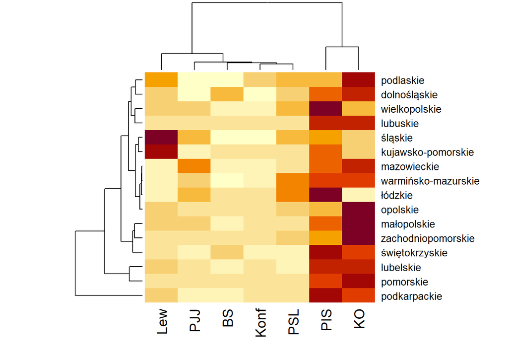

```r
heatmap(E2*E2, scale="row")
```

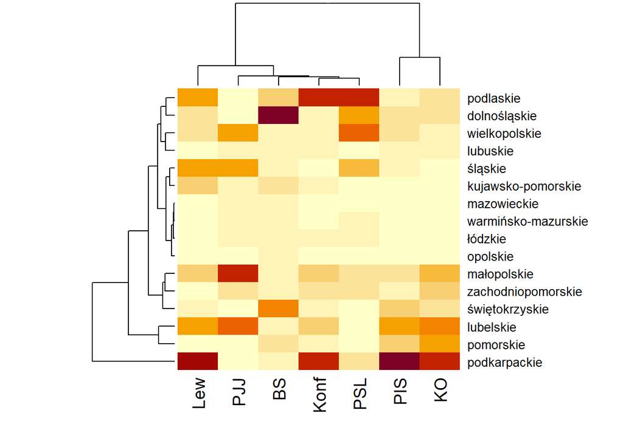

```r
heatmap(E2*E2, scale="col")
```

```r
S <- svd(E2)
str(S)
```

```
## List of 3
##  $ d: num [1:7] 0.1719 0.0452 0.0328 0.0325 0.022 ...
##  $ u: num [1:16, 1:7] -0.2439 -0.1183 0.4082 -0.1779 0.0339 ...
##  $ v: num [1:7, 1:7] -0.0229 0.0348 -0.2972 0.655 0.1568 ...
```

Korzystając z powyższej dekompozycji macierzy $E2\cdot E2^T$ standaryzując współrzędne wierszy i kolumn otrzymujemy wykres postaci:

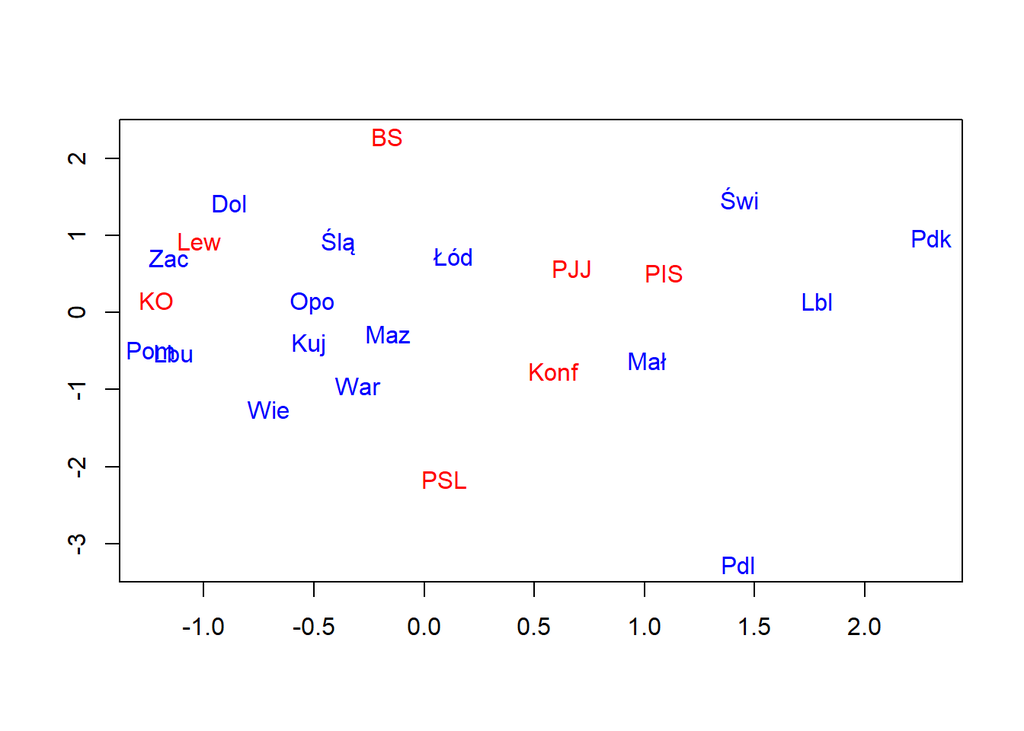

```r
X <- diag(1/sqrt(masa_w)) %*% S$u
Y <- diag(1/sqrt(masa_k)) %*% S$v
plot(rbind(X[,1:2], Y[,1:2]), col = "white", xlab = "", ylab = "", main = "")
text(X[,1:2], c("Dol", "Kuj", "Lbl", "Lbu", "Łód", "Mał", "Maz", "Opo", "Pdk", "Pdl", "Pom", "Ślą", "Świ", "War", "Wie", "Zac"), col = "blue")
text(Y[,1:2], colnames(wyniki_2023_woj[, 1:7]), col = "red")
```

```r
library(rgl)
rownames(wyniki_2023_woj) <- NULL
dane2 <- as.matrix(wyniki_2023_woj)[, 1:7]
plot3d(ca(dane2))
rglwidget()
```

[interactive chart not shown]

Z wykresu tego jesteśmy już w stanie jawnie odczytać zależności występujące w badanych danych.